# Assignment 3

**A. Understanding variables and relations in data (2 points)**

**A.1. Discuss how credit and payment history data such as PAY_AMT1 have an impact on payment default.**

| Variable | Data Type | Potential impact on “Default” and reason |
| --- | --- | --- |
| Limit_Bal | numeric | The higher the limit balance the higher the likelihood of default |
| Pay_0, 2, 3, 4, 5, 6 | integer | The lower the payment status the lower the likelihood of default |
| Bill_Amt1, 2, 3, 4, 5, 6 | numeric | The higher the amount of bill statement the higher the likelihood of default |
| Pay_Amt1, 2, 3, 4, 5, 6 | numeric | The higher the amount of previous payment the lower the likelihood of default |

**A.2. Discuss in what ways some of the above attributes contribute to default.payment.next.month together. Please identify at least two pairs of attributes that can be treated together and how.**

| Variable 1 | Variable 2 | Discuss their relation, how to combine them (ratio, difference, or others) and your reason/theory |
| --- | --- | --- |
| Limit_Bal | Bill_Amt1, 2, 3, 4, 5, 6 | We can determine the credit utilization rate using these two variables. (Bil_Amt divided by Limit_Bal). The higher the utilization rate the higher the likelihood of default. |
| Bill_Amt1, 2, 3, 4, 5, 6 | Pay_Amt1, 2, 3, 4, 5, 6 | Pay_Amt divided by Bil_Amt. This ratio shows if the user is struggling to meet financial obligations. For example, high bill amount with smaller previous payment amount may result in higher likelihood… |

Note it is possible that more than two variables can be taken together. If that is the case, extend the above table to accommodate more than two variables. You may review week 7 tutorials on transforming web filter data for related ideas.

**B. Data preparation and cleansing (1 points)**

**B.1.Load data and initial data conversion/transformation:**

1. Load “UCI_Credit_Card.csv” into data frame variable in R using read.csv().

```r
library(ggplot2)
cc <- read.csv("UCI_Credit_Card.csv")
```

2. Convert the following variables into as nominal (categorical, factor) variables: Sex, Education, Marriage, Pay_ ?and default.payment.next.month. Transform related demographic variables into nominal values with proper labels using the factor() function.

```r
cc$SEX <- factor(cc$SEX,levels=c(1,2), labels=c("Male", "Female"))
```

```r
cc$EDUCATION <- factor(cc$EDUCATION,levels=c(1,2,3,4,5,6), labels=c("graduate school","university","high school", "others", "unknown", "unknown"))
```

```r
cc$MARRIAGE <- factor(cc$MARRIAGE,levels=c(1,2,3), labels=c("married", "single", "others"))
```

- Since the word labels of PAY_0, PAY_2, PAY_3, PAY_4, PAY_5, PAY_6 are too long for the graphs, I am going to label them with numbers. -2 = “no balance”, -1 = “pay duly”, 0 = “pay minimum”, 1 = “delay one month”, 2 = “delay two months”, 3 = “delay three months”, 4 = “delay four months”, 5 = “delay five months”, 6 = “delay six months”, 7 = “delay seven months”, 8 = “delay eight months”, 9 = “delay nine months and above”

```r
cc$PAY_0 <- factor(cc$PAY_0,levels=c(-2, -1, 0, 1, 2, 3, 4, 5, 6, 7, 8, 9), labels=c("-2", "-1", "0", "1", "2", "3", "4", "5", "6", "7", "8", "9"))
```

```r
cc$PAY_2 <- factor(cc$PAY_2,levels=c(-2, -1, 0, 1, 2, 3, 4, 5, 6, 7, 8, 9), labels=c("-2", "-1", "0", "1", "2", "3", "4", "5", "6", "7", "8", "9"))
```

```r
cc$PAY_3 <- factor(cc$PAY_3,levels=c(-2, -1, 0, 1, 2, 3, 4, 5, 6, 7, 8, 9), labels=c("-2", "-1", "0", "1", "2", "3", "4", "5", "6", "7", "8", "9"))
```

```r
cc$PAY_4 <- factor(cc$PAY_4,levels=c(-2, -1, 0, 1, 2, 3, 4, 5, 6, 7, 8, 9), labels=c("-2", "-1", "0", "1", "2", "3", "4", "5", "6", "7", "8", "9"))
```

```r
cc$PAY_5 <- factor(cc$PAY_5,levels=c(-2, -1, 0, 1, 2, 3, 4, 5, 6, 7, 8, 9), labels=c("-2", "-1", "0", "1", "2", "3", "4", "5", "6", "7", "8", "9"))
```

```r
cc$PAY_6 <- factor(cc$PAY_6,levels=c(-2, -1, 0, 1, 2, 3, 4, 5, 6, 7, 8, 9), labels=c("-2", "-1", "0", "1", "2", "3", "4", "5", "6", "7", "8", "9"))
```

```r
cc$default.payment.next.month <- factor(cc$default.payment.next.month,levels=c(0,1), labels=c("No","Yes"))
```

3. Use class() function check on Sex, Education, Marriage, Pay_? and default.payment.next.month, they should ALL be “factor” variables.

```r
class(cc$SEX)
```

```
[1] "factor"
```

```r
class(cc$EDUCATION)
```

```
[1] "factor"
```

```r
class(cc$MARRIAGE)
```

```
[1] "factor"
```

```r
class(cc$PAY_0)
```

```
[1] "factor"
```

```r
class(cc$default.payment.next.month)
```

```
[1] "factor"
```

**B.2. Create a filtered data set with only non-negative amounts.**

1. Use the subset() function to select only positive values on the 6 BILL_AMT variables and 6 PAY_AMT variables.

```r
ccnn <- subset(cc, BILL_AMT1>=0 & BILL_AMT2 >=0 & BILL_AMT3 >=0 & BILL_AMT4 >=0 & BILL_AMT5 >=0 & BILL_AMT6 >=0 & PAY_AMT1>=0 & PAY_AMT2>=0 & PAY_AMT3>=0 & PAY_AMT4>=0 & PAY_AMT5>=0 & PAY_AMT6>=0)

nrow(ccnn)
```

```
[1] 28070
```

2. Check the number of rows in the filtered subset and you can use View(ccpo) to double check on the data.

```r
View(ccnn)
```

**C. Data Transformation and Classification/Modeling (4 points)**

**C.1. Pick one classification method, model with default.payment.next.month ~ variables in A.1., and evaluate:**

- You can pick one of these methods: Naïve Bayes, Decision Tree, SVM, and Neural Networks, Logistic Regression, among others we have discussed.
- Select 90% of data for training and 10% for testing; • Build a model with training data (90% data) to predict default.payment.next.month, using at least three variables from A.1.

```r
set.seed(123)  # For reproducibility
train_indices <- sample(1:nrow(ccnn), 0.9 * nrow(ccnn))  # 90% for training
train <- ccnn[train_indices, ]
test <- ccnn[-train_indices, ]
```

- Run prediction with the model on test data (10% data) and record the following scores: o Present the confusion table with TP, TN, FP, and FN o Report Accuracy, Precision, Recall, F, and Kappa in Table D.

```r
library(e1071)
nb <- naiveBayes(default.payment.next.month ~ LIMIT_BAL + BILL_AMT1 + PAY_AMT1, data = train)
```

```r
predictions <- predict(nb, newdata = test)
```

```r
library(caret)
library(knitr)
confusion <- confusionMatrix(predictions, test$default.payment.next.month)

TP <- confusion$table[2, 2]  # True positives
TN <- confusion$table[1, 1]  # True negatives
FP <- confusion$table[1, 2]  # False positives
FN <- confusion$table[2, 1]  # False negatives

accuracy <- confusion$overall["Accuracy"]
precision <- confusion$byClass["Pos Pred Value"]
recall <- confusion$byClass["Sensitivity"]
F_measure <- confusion$byClass["F1"]
kappa <- confusion$overall["Kappa"]

# Print the confusion table
kable(confusion$table)
```

|  | No | Yes |
| --- | --- | --- |
| No | 2158 | 649 |
| Yes | 0 | 0 |

```r
# Print the performance metrics
metrics_table <- data.frame(TP, TN, FP, FN, accuracy, precision, recall, F_measure, kappa)
kable(metrics_table)
```

|  | TP | TN | FP | FN | accuracy | precision | recall | F_measure | kappa |
| --- | --- | --- | --- | --- | --- | --- | --- | --- | --- |
| Accuracy | 0 | 2158 | 649 | 0 | 0.7687923 | 0.7687923 | 1 | 0.869285 | 0 |

```r
NA
```

**C.2. Perform data transformation (with new relational attributes) and redo classification:**

1. Follow the treatments (at least two relations) of the variable pairs you have identified in A.2;
2. Create new variables that compute the relations you have identified in A.2;
- Treatment 1: Determine the credit utilization rate using Bill_Amt and Limit_Bal. The higher the utilization rate the higher the likelihood of default.

  Credit utilization = Bill_Amt / Limit_Bal
  - Create 6 new columns named “Credit_util1”, “Credit_util2”,“Credit_util3”,“Credit_util4”,“Credit_util5”,“Credit_util6” corresponding to “Bill_Amt1” divided by Limit_Bal,… “Bill_Amt6” divded Limit_Bal into a new data frame

```r
# New data frame
ccnn_update <- data.frame(ccnn)

ccnn_update['Credit_util1'] = ccnn_update['BILL_AMT1'] / ccnn_update['LIMIT_BAL']
ccnn_update['Credit_util2'] = ccnn_update['BILL_AMT2'] / ccnn_update['LIMIT_BAL']
ccnn_update['Credit_util3'] = ccnn_update['BILL_AMT3'] / ccnn_update['LIMIT_BAL']
ccnn_update['Credit_util4'] = ccnn_update['BILL_AMT4'] / ccnn_update['LIMIT_BAL']
ccnn_update['Credit_util5'] = ccnn_update['BILL_AMT5'] / ccnn_update['LIMIT_BAL']
ccnn_update['Credit_util6'] = ccnn_update['BILL_AMT6'] / ccnn_update['LIMIT_BAL']
```

- Treatment 2: Determine whether the user is struggling to meet financial obligations or not by using “Pay_Amt” divided by “Bil_Amt”.For example, high bill amount with smaller previous payment amount may result in higher likelihood of default.

  Payment_ratio = Pay_Amt / Bill_Amt
  - Create 6 new columns named “Payment_ratio1”, “Payment_ratio2”,“Payment_ratio3”, “Payment_ratio4”, “Payment_ratio5,”Payment_ratio6”” corresponding to “Pay_Amt1” divided by Bill_Amt1,..,“Pay_Amt6” divided by “Bill_Amt6”.

````
```r
ccnn_update['Payment_Ratio1'] = ccnn_update['PAY_AMT1'] / ccnn_update['BILL_AMT1']
ccnn_update['Payment_Ratio2'] = ccnn_update['PAY_AMT2'] / ccnn_update['BILL_AMT2']
ccnn_update['Payment_Ratio3'] = ccnn_update['PAY_AMT3'] / ccnn_update['BILL_AMT3']
ccnn_update['Payment_Ratio4'] = ccnn_update['PAY_AMT4'] / ccnn_update['BILL_AMT4']
ccnn_update['Payment_Ratio5'] = ccnn_update['PAY_AMT5'] / ccnn_update['BILL_AMT5']
ccnn_update['Payment_Ratio6'] = ccnn_update['PAY_AMT6'] / ccnn_update['BILL_AMT6']
```
````

```
-   Since there are some "0" values in numerators and denominators, we replace NaN and Inf values with 0 in the 'Payment_Ratio' columns (1-6)
```

```r
ccnn_update$Payment_Ratio1 <- ifelse(is.nan(ccnn_update$Payment_Ratio1) | is.infinite(ccnn_update$Payment_Ratio1), 0, ccnn_update$Payment_Ratio1)
ccnn_update$Payment_Ratio2 <- ifelse(is.nan(ccnn_update$Payment_Ratio2) | is.infinite(ccnn_update$Payment_Ratio2), 0, ccnn_update$Payment_Ratio2)
ccnn_update$Payment_Ratio3 <- ifelse(is.nan(ccnn_update$Payment_Ratio3) | is.infinite(ccnn_update$Payment_Ratio3), 0, ccnn_update$Payment_Ratio3)
ccnn_update$Payment_Ratio4 <- ifelse(is.nan(ccnn_update$Payment_Ratio4) | is.infinite(ccnn_update$Payment_Ratio4), 0, ccnn_update$Payment_Ratio4)
ccnn_update$Payment_Ratio5 <- ifelse(is.nan(ccnn_update$Payment_Ratio5) | is.infinite(ccnn_update$Payment_Ratio5), 0, ccnn_update$Payment_Ratio5)
ccnn_update$Payment_Ratio6 <- ifelse(is.nan(ccnn_update$Payment_Ratio6) | is.infinite(ccnn_update$Payment_Ratio6), 0, ccnn_update$Payment_Ratio6)
```

- Check table again with view column

```r
View(ccnn_update)
```

3. Build a model with training data (90% data) to predict default.payment.next.month, using the new relational attributes (plus any other variables you would like to include) here.

```r
set.seed(123)  # For reproducibility
train_indices_update <- sample(1:nrow(ccnn_update), 0.9 * nrow(ccnn_update))  # 90% for training
train_update <- ccnn_update[train_indices_update, ]
test_update <- ccnn_update[-train_indices_update, ]
```

4. Run prediction with the model on test data (10% data) and record the following scores:

**Treatment 1**: with Credit_util1

```
a\. Present the confusion table with TP, TN, FP, and FN
```

```r
nb_update1 <- naiveBayes(default.payment.next.month ~ LIMIT_BAL + BILL_AMT1 + PAY_AMT1 + Credit_util1, data = train_update)
```

```r
predictions_update1 <- predict(nb_update1, newdata = test_update)
```

```r
confusion_update1 <- confusionMatrix(predictions_update1, test_update$default.payment.next.month)

TP <- confusion_update1$table[2, 2]  # True positives
TN <- confusion_update1$table[1, 1]  # True negatives
FP <- confusion_update1$table[1, 2]  # False positives
FN <- confusion_update1$table[2, 1]  # False negatives

accuracy <- confusion_update1$overall["Accuracy"]
precision <- confusion_update1$byClass["Pos Pred Value"]
recall <- confusion_update1$byClass["Sensitivity"]
F_measure <- confusion_update1$byClass["F1"]
kappa <- confusion_update1$overall["Kappa"]

# Print the confusion table
kable(confusion_update1$table)
```

|  | No | Yes |
| --- | --- | --- |
| No | 1913 | 569 |
| Yes | 245 | 80 |

```
b\. Report Accuracy, Precision, Recall, F, and Kappa in Table D.
```

```r
# Print the performance metrics
metrics_table <- data.frame(TP, TN, FP, FN, accuracy, precision, recall, F_measure, kappa)
kable(metrics_table)
```

|  | TP | TN | FP | FN | accuracy | precision | recall | F_measure | kappa |
| --- | --- | --- | --- | --- | --- | --- | --- | --- | --- |
| Accuracy | 80 | 1913 | 569 | 245 | 0.7100107 | 0.7707494 | 0.886469 | 0.824569 | 0.0117941 |

**Treatment 2:** with Payment_Ratio1

a. Present the confusion table with TP, TN, FP, and FN

```r
nb_update2 <- naiveBayes(default.payment.next.month ~ LIMIT_BAL + BILL_AMT1 + PAY_AMT1 + Payment_Ratio1  , data = train_update)
```

```r
predictions_update2 <- predict(nb_update2, newdata = test_update)
```

```r
confusion_update2 <- confusionMatrix(predictions_update2, test_update$default.payment.next.month)

TP <- confusion_update2$table[2, 2]  # True positives
TN <- confusion_update2$table[1, 1]  # True negatives
FP <- confusion_update2$table[1, 2]  # False positives
FN <- confusion_update2$table[2, 1]  # False negatives

accuracy <- confusion_update2$overall["Accuracy"]
precision <- confusion_update2$byClass["Pos Pred Value"]
recall <- confusion_update2$byClass["Sensitivity"]
F_measure <- confusion_update2$byClass["F1"]
kappa <- confusion_update2$overall["Kappa"]

# Print the confusion table
kable(confusion_update2$table)
```

|  | No | Yes |
| --- | --- | --- |
| No | 200 | 25 |
| Yes | 1958 | 624 |

```
b\. Report Accuracy, Precision, Recall, F, and Kappa in Table D.
```

```r
# Print the performance metrics
metrics_table <- data.frame(TP, TN, FP, FN, accuracy, precision, recall, F_measure, kappa)
kable(metrics_table)
```

|  | TP | TN | FP | FN | accuracy | precision | recall | F_measure | kappa |
| --- | --- | --- | --- | --- | --- | --- | --- | --- | --- |
| Accuracy | 624 | 200 | 25 | 1958 | 0.2935518 | 0.8888889 | 0.0926784 | 0.1678556 | 0.0265303 |

- The second treatment using Payment_Ratio1 results in a low accuracy of 0.2935518. Therefore, we will use treatment 1 for this model.

**C.3. Examine attribute value distribution (histogram), and perform log transformation on attributes you see fit:**

1. Create a new attribute that is the logarithm of each attribute with an extremely wide, “skew” distribution.

```r
# remove 0 values to avoid -inf
ccnn_update <- subset(ccnn_update, rowSums(ccnn_update == 0 | ccnn_update == 0.000000000) == 0)


ccnn_update
```

[output not shown]

[output cut: 990 more lines]

```r
ccnn_update_log <- data.frame(ccnn_update)

ccnn_update_log$LIMIT_BALl <- log(ccnn_update_log$LIMIT_BAL)

ccnn_update_log$BILL_AMT1l <- log(ccnn_update_log$BILL_AMT1)
ccnn_update_log$BILL_AMT2l <- log(ccnn_update_log$BILL_AMT2)
ccnn_update_log$BILL_AMT3l <- log(ccnn_update_log$BILL_AMT3)
ccnn_update_log$BILL_AMT4l <- log(ccnn_update_log$BILL_AMT4)
ccnn_update_log$BILL_AMT5l <- log(ccnn_update_log$BILL_AMT5)
ccnn_update_log$BILL_AMT6l <- log(ccnn_update_log$BILL_AMT6)

ccnn_update_log$PAY_AMT1l <- log(ccnn_update_log$PAY_AMT1)
ccnn_update_log$PAY_AMT2l <- log(ccnn_update_log$PAY_AMT2)
ccnn_update_log$PAY_AMT3l <- log(ccnn_update_log$PAY_AMT3)
ccnn_update_log$PAY_AMT4l <- log(ccnn_update_log$PAY_AMT4)
ccnn_update_log$PAY_AMT5l <- log(ccnn_update_log$PAY_AMT5)
ccnn_update_log$PAY_AMT6l <- log(ccnn_update_log$PAY_AMT6)

ccnn_update_log$Credit_util1l <- log(ccnn_update_log$Credit_util1)
ccnn_update_log$Credit_util2l <- log(ccnn_update_log$Credit_util2)
ccnn_update_log$Credit_util3l <- log(ccnn_update_log$Credit_util3)
ccnn_update_log$Credit_util4l <- log(ccnn_update_log$Credit_util4)
ccnn_update_log$Credit_util5l <- log(ccnn_update_log$Credit_util5)
ccnn_update_log$Credit_util6l <- log(ccnn_update_log$Credit_util6)
```

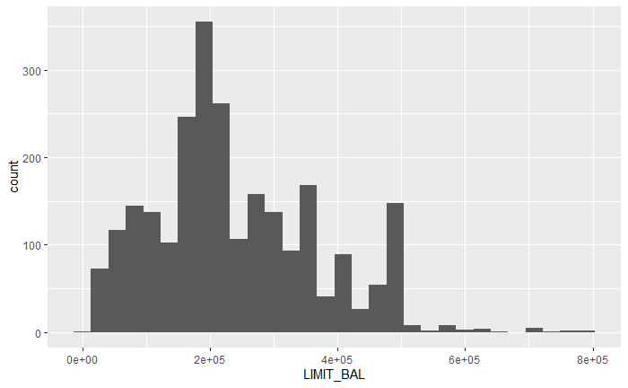

```r
#Histograms before transformation
library(ggplot2)
ggplot(ccnn_update, aes(x = LIMIT_BAL)) +
  geom_histogram()
```

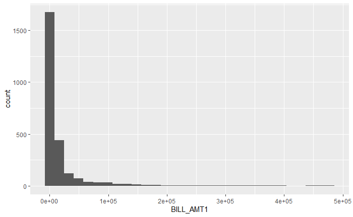

```r
ggplot(ccnn_update, aes(x = BILL_AMT1)) +
  geom_histogram()
```

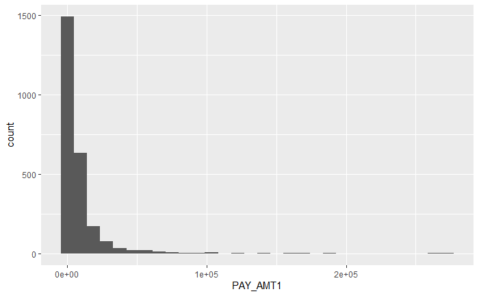

```r
ggplot(ccnn_update, aes(x = PAY_AMT1)) +
  geom_histogram()
```

```r
ggplot(ccnn_update, aes(x = Credit_util1)) +
  geom_histogram()
```

[output not shown]

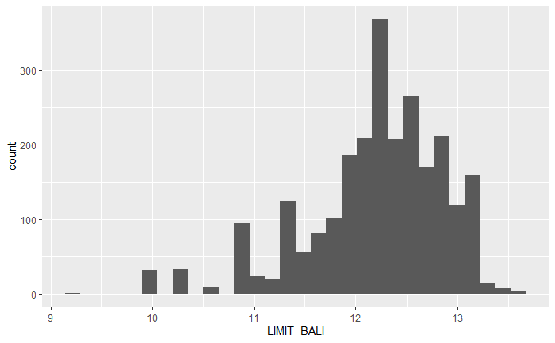

```r
# histograms after
library(ggplot2)
ggplot(ccnn_update_log, aes(x = LIMIT_BALl)) +
  geom_histogram()
```

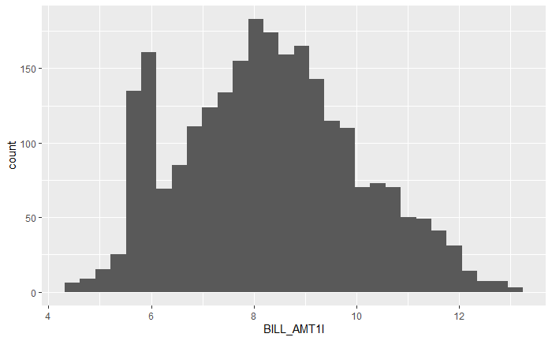

```r
ggplot(ccnn_update_log, aes(x = BILL_AMT1l)) +
  geom_histogram()
```

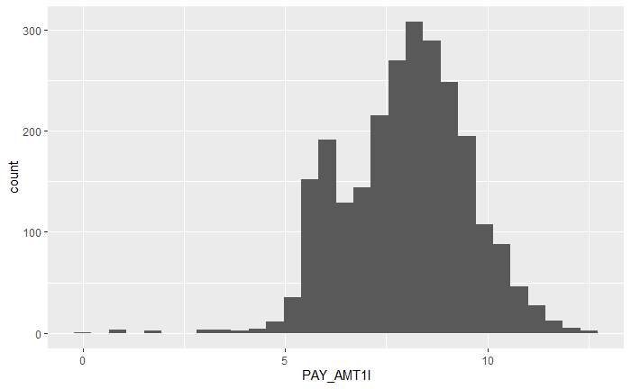

```r
ggplot(ccnn_update_log, aes(x = PAY_AMT1l)) +
  geom_histogram()
```

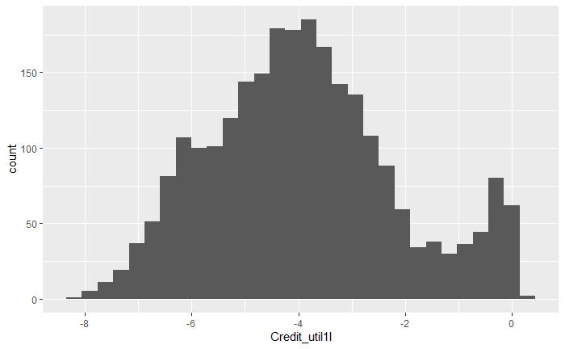

```r
ggplot(ccnn_update_log, aes(x = Credit_util1l)) +
  geom_histogram()
```

2. Remove attributes that are no longer needed in your analysis.

```r
ccnn_update_log$LIMIT_BAL <- NULL
ccnn_update_log$BILL_AMT1 <- NULL
ccnn_update_log$BILL_AMT2 <- NULL
ccnn_update_log$BILL_AMT3 <- NULL
ccnn_update_log$BILL_AMT4 <- NULL
ccnn_update_log$BILL_AMT5 <- NULL
ccnn_update_log$BILL_AMT6 <- NULL
ccnn_update_log$PAY_AMT1 <- NULL
ccnn_update_log$PAY_AMT2 <- NULL
ccnn_update_log$PAY_AMT3 <- NULL
ccnn_update_log$PAY_AMT4 <- NULL
ccnn_update_log$PAY_AMT5 <- NULL
ccnn_update_log$PAY_AMT6 <- NULL
ccnn_update_log$Credit_util1 <- NULL
ccnn_update_log$Credit_util2 <- NULL
ccnn_update_log$Credit_util3 <- NULL
ccnn_update_log$Credit_util4 <- NULL
ccnn_update_log$Credit_util5 <- NULL
ccnn_update_log$Credit_util6 <- NULL
```

3. Hopefully data distributions now look “normal”.
4. Build a model with training data (90% data) to predict default.payment.next.month, using at the new relational (and log-transformed) attributes plus any other variables you would like to include here.

```r
set.seed(123)  # For reproducibility
train_indices <- sample(1:nrow(ccnn_update_log), 0.9 * nrow(ccnn_update_log))  # 90% for training
train_log <- ccnn_update_log[train_indices, ]
test_log <- ccnn_update_log[-train_indices, ]

nb_log <- naiveBayes(default.payment.next.month ~ LIMIT_BALl + BILL_AMT1l + PAY_AMT1l + Credit_util1l, data = train_log)
```

5. Run prediction with the model on test data (10% data) and record the following scores:

   a. Present the confusion table with TP, TN, FP, and FN

   b. Report Accuracy, Precision, Recall, F, and Kappa in Table D.

```r
predictions_log <- predict(nb_log, newdata = test_log)
```

```r
confusion_log <- confusionMatrix(predictions_log, test_log$default.payment.next.month)

TP <- confusion_log$table[2, 2]  # True positives
TN <- confusion_log$table[1, 1]  # True negatives
FP <- confusion_log$table[1, 2]  # False positives
FN <- confusion_log$table[2, 1]  # False negatives

accuracy <- confusion_log$overall["Accuracy"]
precision <- confusion_log$byClass["Pos Pred Value"]
recall <- confusion_log$byClass["Sensitivity"]
F_measure <- confusion_log$byClass["F1"]
kappa <- confusion_log$overall["Kappa"]

# Print the confusion table
kable(confusion_log$table)
```

|  | No | Yes |
| --- | --- | --- |
| No | 195 | 28 |
| Yes | 10 | 17 |

```r
metrics_table <- data.frame(TP, TN, FP, FN, accuracy, precision, recall, F_measure, kappa)
kable(metrics_table)
```

|  | TP | TN | FP | FN | accuracy | precision | recall | F_measure | kappa |
| --- | --- | --- | --- | --- | --- | --- | --- | --- | --- |
| Accuracy | 17 | 195 | 28 | 10 | 0.848 | 0.8744395 | 0.9512195 | 0.911215 | 0.3898523 |

**C.4. Pick another classification model or the same model with different parameter values, and repeat the modeling and evaluation as in C.3. Report the confusion table and results to Table D.**

```r
library(rpart)

# Train a decision tree classifier
decision_tree <- rpart(default.payment.next.month ~ LIMIT_BALl + BILL_AMT1l + PAY_AMT1l + Credit_util1l, data = train_log, method = "class")
predictions_dt <- predict(decision_tree, newdata = test_log, type = "class")

confusion_dt <- confusionMatrix(predictions_dt, test_log$default.payment.next.month)

TP <- confusion_dt$table[2, 2]  # True positives
TN <- confusion_dt$table[1, 1]  # True negatives
FP <- confusion_dt$table[1, 2]  # False positives
FN <- confusion_dt$table[2, 1]  # False negatives

accuracy <- confusion_dt$overall["Accuracy"]
precision <- confusion_dt$byClass["Pos Pred Value"]
recall <- confusion_dt$byClass["Sensitivity"]
F_measure <- confusion_dt$byClass["F1"]
kappa <- confusion_dt$overall["Kappa"]

# Print the confusion table
kable(confusion_dt$table)
```

|  | No | Yes |
| --- | --- | --- |
| No | 196 | 38 |
| Yes | 9 | 7 |

```r
metrics_table <- data.frame(TP, TN, FP, FN, accuracy, precision, recall, F_measure, kappa)
kable(metrics_table)
```

|  | TP | TN | FP | FN | accuracy | precision | recall | F_measure | kappa |
| --- | --- | --- | --- | --- | --- | --- | --- | --- | --- |
| Accuracy | 7 | 196 | 38 | 9 | 0.812 | 0.8376068 | 0.9560976 | 0.8929385 | 0.1491673 |

**D. Evaluation and Results (2 points)**

|  |  | Correct % | Precision | Recall | F | Kappa |
| --- | --- | --- | --- | --- | --- | --- |
| C1 | NB with LIMIT_BAL1, BILL_AMT1, PAY_AMT1 | 0.7687923 | 0.7687923 | 1 | 0.869285 | 0 |
| C2 | NB with LIMIT_BAL1, BILL_AMT1, PAY_AMT1, Credit_util1 | 0.7100107 | 0.7707494 | 0.886469 | 0.824569 | 0.01179413 |
| C3 | NB with LIMIT_BAL1l, BILL_AMT1l, PAY_AMT1l, Credit_util1l | 0.848 | 0.8744395 | 0.9512195 | 0.911215 | 0.3898523 |
| C4 | DT with LIMIT_BAL1l, BILL_AMT1l, PAY_AMT1l, Credit_util1l | 0.812 | 0.8376068 | 0.9560976 | 0.8929385 | 0.1491673 |

**E. Report with Interpretation and Conclusion (3 points)**

Discuss the results in Task D and answer the following questions:

**E.1. In terms of the reasons and theories presented in tasks A1 through A2, which ones have been confirmed by your analysis? Please discuss even if there is no obvious answer.**

**E.2. Does data transformation (with new relational variables in C.2) help? Which one helps most and why? Or which does not?**

- In C3 model, we performed the following transformation. First, we remove the all the rows with 0 values. Then we applied the log transformation to address the skewness of data distribution. These two steps help improve the performance of the model. Accuracy is increased to 0.848 from 0.7100107. Precision is increased to 0.8744395 from 0.7707494.
- The log transform is helpful because it address the skewness of data distribution.

**E.3. Which classification method(s) and/or parameters appear to perform well? Which ones do not?**

**E.4. Reviewing results in Task D, which evaluation metrics (of Correct%, Kappa, F, Precision, and Recall) best capture how good/poor the result is? Which metric is not as helpful?**

- The evaluation metrics that best capture how good the results are include precision, recall, F1-score, and Kappa. These metrics provide a comprehensive assessment of the model’s performance, considering both false positives and false negatives.
- Accuracy (Correct%) alone is not as helpful for assessing model performance, especially in the case of imbalanced data set. It does not provide insights into the model’s ability to correctly identify default cases or avoid false positives..

**E.5. Pick the most helpful evaluation metric, which method (with what data transformation if applicable) is the overall winner of the results? Reason about why the method performs well.**

- The evaluation metric that best captures this requirement is the F, which combines precision and recall into a single metric, giving equal importance to both. It provides a balanced measure of the model’s performance by considering false positives and false negatives.

C1: F1 = 0.869285

C2: F1 = 0.824569

C3: F1 = 0.911215

C4: F1 = 0.8929385